# Academic Performance: Expectation, Residency and Grade Inflation

## What are the potential biases?

Within this data set there are multiple biases, but primarily on account of the types of questions asked a response bias is present, and on account of the types of students that are inclined to respond to surveys, a selection bias is present. To determine weather a selection bias exists an additional chi-squared test for homogeneity among populations of data2902 and data2002. Under the null hypothesis the proportions of students in data2902 who responded, and data2002 who responded would be the same. This is an appropriate null hypothesis to test for independence of the two groups, as later through the report we will be analyzing traits of HD students of the sample of survey respondents.

```r
cols = c("respondants", "non-respondants")
rows = c("data2002", "data2902")
totals = c(675, 84)
responses = c(sum(x$enrolled_unit == "DATA2002", na.rm = TRUE),
              sum(x$enrolled_unit == "DATA2902", na.rm = TRUE)
              )
non_responses = totals-responses
mat = matrix(c(non_responses, responses), 2,2)
intro_test = chisq.test(mat, correct=FALSE)
```

Here the assumption of expected cell counts above 5 (TRUE) is made for the chi-squared approximation to be appropriate; a criteria that is met. Calculating the p-value with an p >= 0.05 threshold for significance gives a p value of 0; hence implying that there is a clear selection bias in the respondents of the survey. Further, this too provides a more definitive answer to “Is this a random data set of students?” — no, as there is a strong selection bias where data2902 students nominated themselves more frequently.

As for response bias, there are a few poorly asked questions that lead to response bias. Take for instance average hours slept. For many respondents this is a guess, often rounded to the nearest hour. Or for instance height in, which in general populations approximates a normal curve. However in Figure 2 there are a disproportionate amount of people that are of specifically 170cm, or 180cm. Due to the method of data cleaning, all responses in inches were removed as this is only to demonstrate a response bias, but there would be discrete jumps around 6’, were heights recorded in inches included.

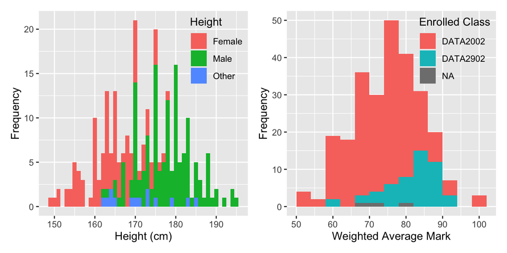

Figure 2: On the left, histogram of heights in DATA2X02 demonstrating artefact binning, and on the right a histogram of Weighted Average Marks (WAM) of students in DATA2X02 sperated by class enrolment

```r
p1 = x |>
  ggplot()+
  aes(x = height_clean,
      fill = gender_clean) +
  geom_histogram(binwidth = 1)+
  labs(x = "Height (cm)", y = "Frequency", fill="Height") +
  theme(
      legend.position = c(1, 1),
      legend.justification = c(1, 1),
      legend.background = element_blank(),
      legend.box.background = element_blank()
    )

p2 = x |>
  ggplot()+
  aes(x = wam_clean,
      fill = enrolled_unit
      ) +
  geom_histogram(binwidth = 4) +
  labs(x = "Weighted Average Mark", y = "Frequency", fill="Enrolled Class") +
  theme(
      legend.position = c(1, 1),
      legend.justification = c(1, 1),
      legend.background = element_blank(),
      legend.box.background = element_blank()
    )

p1  + p2 + plot_layout(ncol = 2)
```

Although it could be argued that the sample in this case does represent normality somewhat accurately, there are “bin artefacts”, or accumulations at the points, 160, 170, 175 and 180. This is one example of response bias where people round heights to the nearest discrete measurement. Similarly, in the plots for weighted average mark (WAM) in Figure 2, rounding too seems to take place at 75, and around grade thresholds. The histogram of student WAM’s visually conforms with an assumption of normality, however due to response bias responses tend to congregate around round grade thresholds such as distinction average (75) and credit average (65). Together this forms clear proof of response bias throught the sample in certain categories.

As a bulk of this report is concerned with performing hypothesis testing on WAM scores of students in order to understand which factors are significant and aren’t significant in student academic performance, and thus data-bias in WAM scores is very important. Although the histogram of WAM scores in Figure 2 does exhibit binning artefacts, it is impossible to conclude because it appears to be a bi modal distribution under DATA2902 and DATA2002 students, and likely many other factors. Nonetheless, these binning artefacts will be addressed through appropriate data-wrangling and analysis with QQ-plots to determine if chosen test statistics are appropriate if normality is assumed. However the best way to mitigate binning artefacts would be through sampling methods and question selection, which will be explored within section 2.3.